# Coursera Reproducible Research

### Peer-graded Assignment: Course Project 1

#### October 25, 2018

## Introduction

It is now possible to collect a large amount of data about personal movement using activity monitoring devices such as a Fitbit, Nike Fuelband, or Jawbone Up. These type of devices are part of the “quantified self” movement - a group of enthusiasts who take measurements about themselves regularly to improve their health, to find patterns in their behavior, or because they are tech geeks. But these data remain under-utilized both because the raw data are hard to obtain and there is a lack of statistical methods and software for processing and interpreting the data.

This assignment makes use of data from a personal activity monitoring device. This device collects data at 5 minute intervals through out the day. The data consists of two months of data from an anonymous individual collected during the months of October and November, 2012 and include the number of steps taken in 5 minute intervals each day.

The data for this assignment are downloaded from the course web site. The dataset is stored in a comma-separated-value (CSV) file and there are a total of 17,568 observations in this dataset.

The variables included in this dataset are:

- steps: Number of steps taking in a 5-minute interval (missing values are coded as NA
- date: The date on which the measurement was taken in YYYY-MM-DD format
- interval: Identifier for the 5-minute interval in which measurement was taken

### 1. Code for reading in the dataset and/or processing the data

```r
# loading libraries; suppress warnings and messages in the output
library(readr)
library(dplyr)
library(ggplot2)
library(lubridate)
```

```r
# set working directory
setwd("H://Mijn documenten/Coursera Training/Reproducible Research/project1")

# reading in the dataset; use read_csv() from the readr-package
if (!file.exists("activity.csv")) {
  tempfile <- tempfile()
  download.file("https://d396qusza40orc.cloudfront.net/repdata%2Fdata%2Factivity.zip", destfile = tempfile)
  unzip(tempfile)
  unlink(tempfile)
}
activity <- read_csv("activity.csv")
glimpse(activity)
```

```
## Observations: 17,568
## Variables: 3
## $ steps    <int> NA, NA, NA, NA, NA, NA, NA, NA, NA, NA, NA, NA, NA, N...
## $ date     <date> 2012-10-01, 2012-10-01, 2012-10-01, 2012-10-01, 2012...
## $ interval <int> 0, 5, 10, 15, 20, 25, 30, 35, 40, 45, 50, 55, 100, 10...
```

### 2. Histogram of the total number of steps taken each day

```r
steps_per_day <- activity %>%
  group_by(date) %>%
  summarize(steps = sum(steps))
glimpse(steps_per_day)
```

```
## Observations: 61
## Variables: 2
## $ date  <date> 2012-10-01, 2012-10-02, 2012-10-03, 2012-10-04, 2012-10...
## $ steps <int> NA, 126, 11352, 12116, 13294, 15420, 11015, NA, 12811, 9...
```

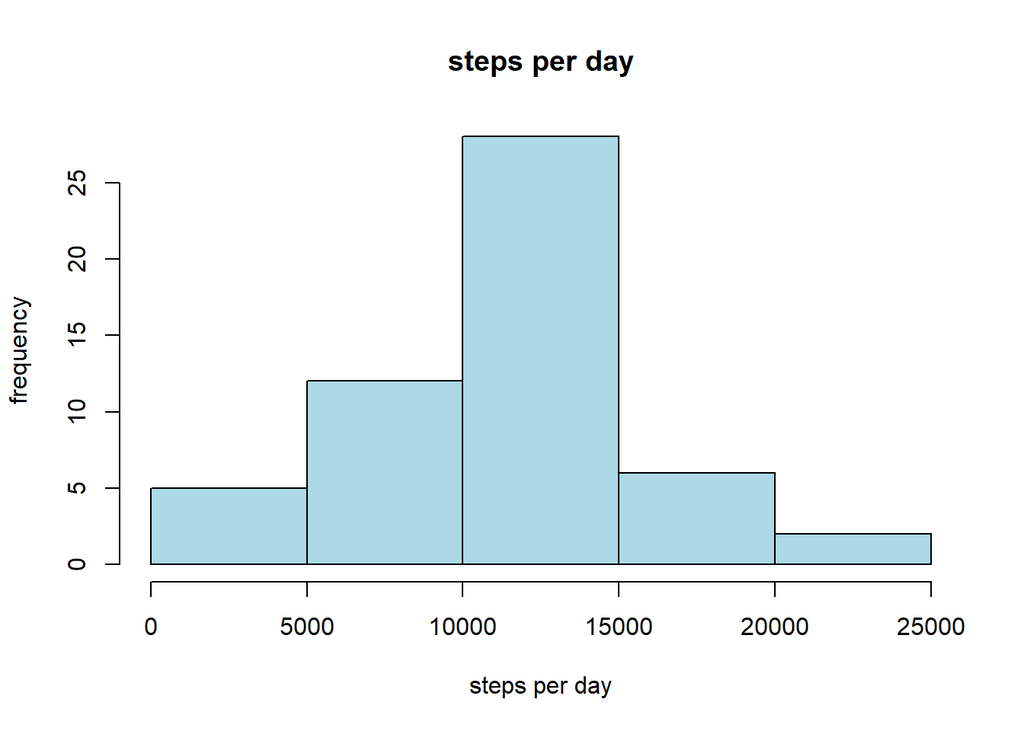

```r
hist(steps_per_day$steps, main = "steps per day", xlab = "steps per day", ylab = "frequency", col = "light blue")
```

### 3. Mean and median number of steps each day

```r
summary(steps_per_day)
```

```
##       date                steps
##  Min.   :2012-10-01   Min.   :   41
##  1st Qu.:2012-10-16   1st Qu.: 8841
##  Median :2012-10-31   Median :10765
##  Mean   :2012-10-31   Mean   :10766
##  3rd Qu.:2012-11-15   3rd Qu.:13294
##  Max.   :2012-11-30   Max.   :21194
##                       NA's   :8
```

```r
mean(steps_per_day$steps, na.rm = TRUE)
```

```
## [1] 10766.19
```

```r
median(steps_per_day$steps, na.rm = TRUE)
```

```
## [1] 10765
```

### 4. Time series plot of the average number of steps taken

```r
steps_per_interval <- activity %>%
  filter(!is.na(steps)) %>%
  group_by(interval) %>%
  summarize(steps = mean(steps))
glimpse(steps_per_interval)
```

```
## Observations: 288
## Variables: 2
## $ interval <int> 0, 5, 10, 15, 20, 25, 30, 35, 40, 45, 50, 55, 100, 10...
## $ steps    <dbl> 1.7169811, 0.3396226, 0.1320755, 0.1509434, 0.0754717...
```

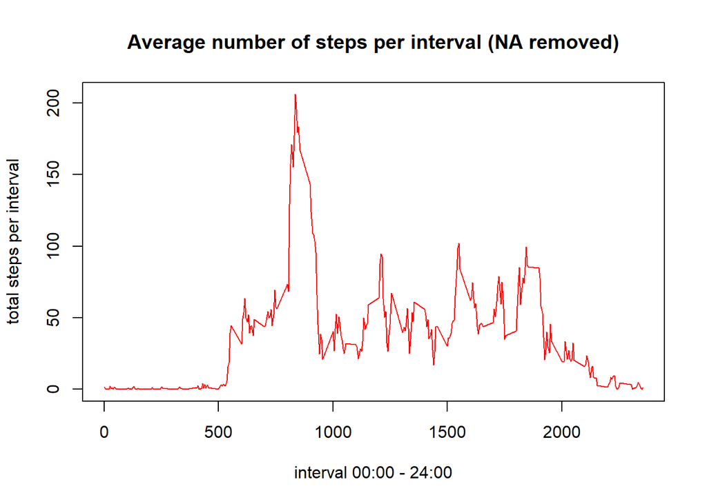

```r
plot(steps_per_interval$interval,
     steps_per_interval$steps,
     type = 'l',
     col = "red",
     xlab = "interval 00:00 - 24:00",
     ylab = "total steps per interval",
     main = "Average number of steps per interval (NA removed)")
```

### 5. The 5-minute interval that, on average, contains the maximum number of steps

```r
(max_steps <- max(steps_per_interval$steps))
```

```
## [1] 206.1698
```

```r
(steps_per_interval$interval[steps_per_interval$steps == max_steps])
```

```
## [1] 835
```

### 6. Code to describe and show a strategy for imputing missing data

```r
# total number of missing values over all variables
sum(apply(activity, 2, is.na))
```

```
## [1] 2304
```

```r
# summary
summary(activity)
```

```
##      steps             date               interval
##  Min.   :  0.00   Min.   :2012-10-01   Min.   :   0.0
##  1st Qu.:  0.00   1st Qu.:2012-10-16   1st Qu.: 588.8
##  Median :  0.00   Median :2012-10-31   Median :1177.5
##  Mean   : 37.38   Mean   :2012-10-31   Mean   :1177.5
##  3rd Qu.: 12.00   3rd Qu.:2012-11-15   3rd Qu.:1766.2
##  Max.   :806.00   Max.   :2012-11-30   Max.   :2355.0
##  NA's   :2304
```

```r
# missings steps per date
activity %>%
  filter(is.na(steps)) %>%
  group_by(date) %>%
  summarize(n = n())
```

```
## # A tibble: 8 x 2
##   date           n
##   <date>     <int>
## 1 2012-10-01   288
## 2 2012-10-08   288
## 3 2012-11-01   288
## 4 2012-11-04   288
## 5 2012-11-09   288
## 6 2012-11-10   288
## 7 2012-11-14   288
## 8 2012-11-30   288
```

```r
# missing steps per interval
activity %>%
  filter(is.na(steps)) %>%
  group_by(interval) %>%
  summarize(n = n())
```

```
## # A tibble: 288 x 2
##    interval     n
##       <int> <int>
##  1        0     8
##  2        5     8
##  3       10     8
##  4       15     8
##  5       20     8
##  6       25     8
##  7       30     8
##  8       35     8
##  9       40     8
## 10       45     8
## # ... with 278 more rows
```

From the summary results we can detect that all missing values are missing steps; in the activity-dataset both other variables (date and interval) have no missing values. Only steps has 2304 missing values.

By looking at the frequency-tables of the missing steps by date and by interval can infer dat some days are missing completely, and this pattern is aknowledged by the missings intervals.

This missing values pattern suggests that it substituting the missing values by the average number of nonmissing steps in the same interval might be a feasible solution.

For readability, the mean number of steps per interval are stored in a separate dataframe (steps_per_interval). Then the activity data is left-joined with this mean number of steps per interval, which is then used to replace missing values by their mean (interval based) values.

```r
steps_per_interval <- activity %>%
  group_by(interval) %>%
  summarize(mean_steps = mean(steps, na.rm = TRUE))
```

```r
activity_NA_removed <- activity %>%
  left_join(steps_per_interval, by = "interval") %>%
  mutate(steps = ifelse(is.na(steps), mean_steps, steps)) %>%
  select(date,interval,steps)

mean(activity$steps, na.rm = TRUE)
```

```
## [1] 37.3826
```

```r
median(activity$steps, na.rm = TRUE)
```

```
## [1] 0
```

```r
mean(activity_NA_removed$steps)
```

```
## [1] 37.3826
```

```r
median(activity_NA_removed$steps)
```

```
## [1] 0
```

The mean and the median of the number of steps over all date-interval-combinations remain exactly the same.

### 7. Histogram of the total number of steps taken each day after missing values are imputed

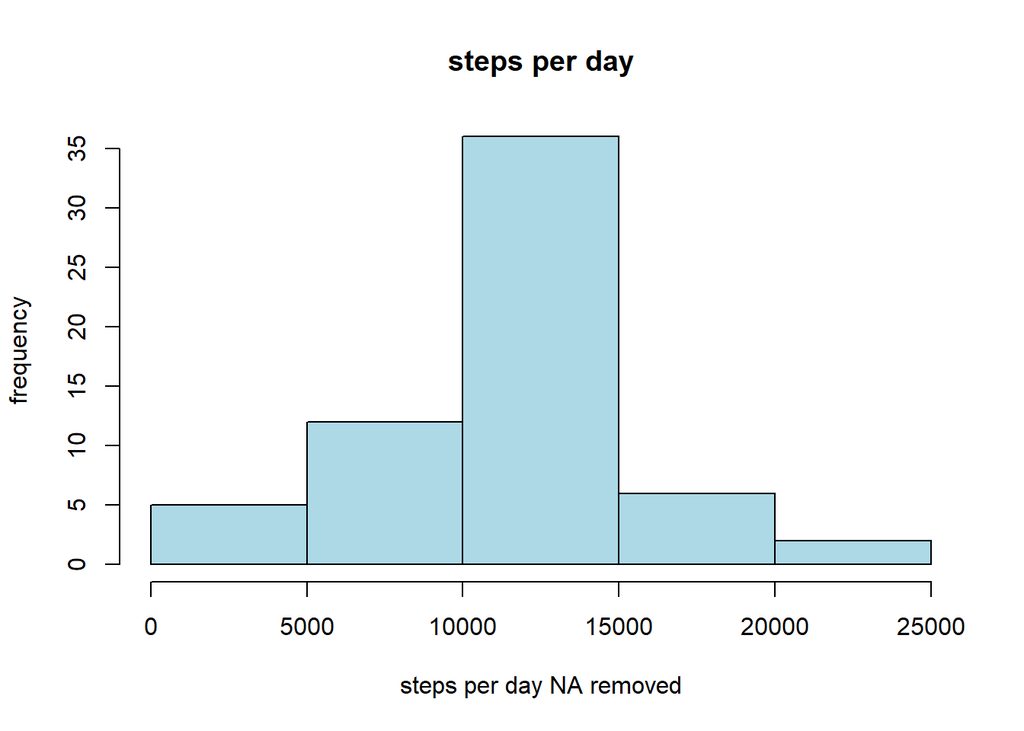

```r
# compute steps per day based on NA-removed
steps_per_day_NA_removed <- activity_NA_removed %>%
  group_by(date) %>%
  summarize(steps = sum(steps))

hist(steps_per_day_NA_removed$steps, main = "steps per day", xlab = "steps per day NA removed", ylab = "frequency", col = "light blue")
```

```r
sd(steps_per_day$steps, na.rm = TRUE)
```

```
## [1] 4269.18
```

```r
sd(steps_per_day_NA_removed$steps)
```

```
## [1] 3974.391
```

### 8. Panel plot comparing the average number of steps taken per 5-minute interval across weekdays and weekends

In th first part of the script below a factor dayType (weekend, weekday) is added to the activity dataframe.

```r
activity$dayType <- factor(ifelse(weekdays(activity$date) %in% c("zaterdag", "zondag"), "weekend", "weekday"))
table(activity$dayType)
```

```
##
## weekday weekend
##   12960    4608
```

Based on this factor (dayType), a graph is made compare the number of steps between weekdays and weekends. To prevent distraction from the interval-fluctuations, a smoothed curve is drawn for both the weekdays and the weekend steps. This shows that on weekdays there is more activity before 10:00, whereas in the weekend there seems to be more activity between 10:00 and 21:00.

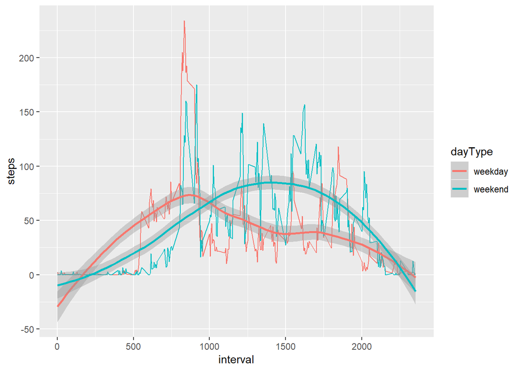

```r
# combined graph weekdays and weekends
activity %>%
  group_by(interval, dayType) %>%
  summarize(steps = mean(steps, na.rm = TRUE)) %>%
  ggplot(aes(x = interval, y = steps, color = dayType)) +
  geom_line() + geom_smooth()
```

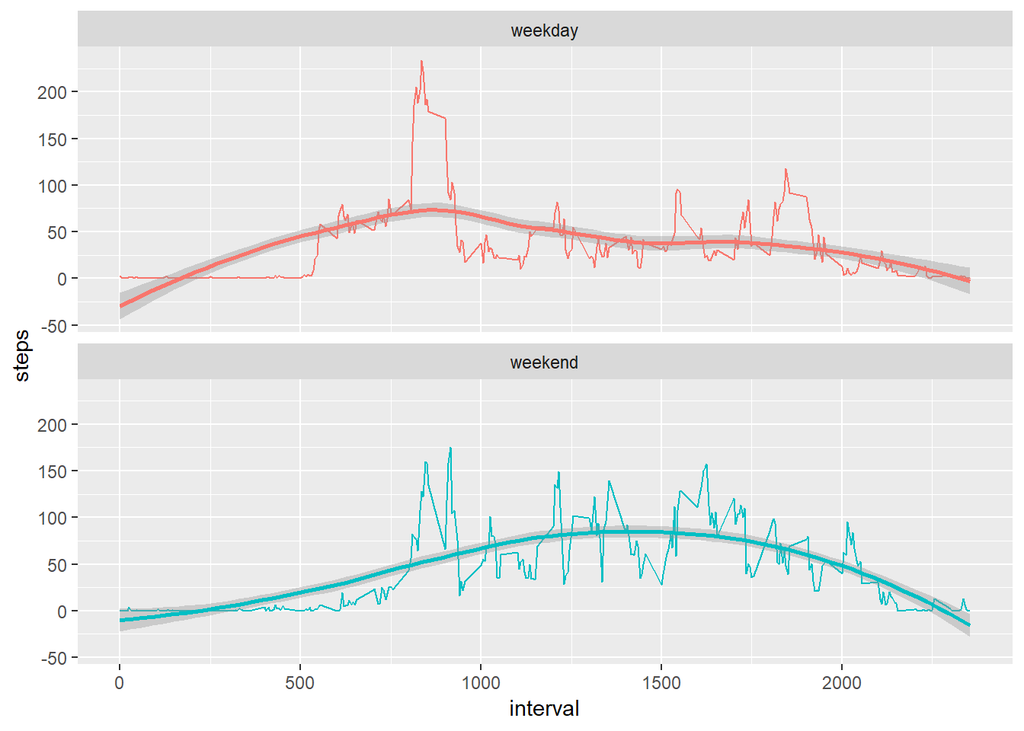

```r
#separate graphs for weekdays and weekends
activity %>%
  group_by(interval, dayType) %>%
  summarize(steps = mean(steps, na.rm = TRUE)) %>%
  ggplot(aes(x = interval, y = steps, color = dayType)) +
  geom_line() + geom_smooth() +
  facet_wrap(~dayType, ncol = 1, nrow = 2) +
  theme(legend.position="none")
```